# Overview

As most new AirBnb landlords will tell you, there’s a lot of stuff you can buy to try to spruce up your property and almost as many [YouTube personalities](https://www.youtube.com/watch?v=WwsMIChMDfE), [news articles](https://qz.com/810309/you-can-earn-10-more-per-night-on-airbnb-just-by-having-a-hair-dryer/) and [blogs](https://optimizemybnb.com/improve-airbnb-amenities/) telling you to do the same. Even AirBnb has released [analysis](https://www.airbnb.com/resources/hosting-homes/a/the-best-amenities-to-offer-right-now-203) (although no data) to try to help guide landlords trying to decide how or whether to improve their listings.

Motivated by my own frustration with trying to guess what amenities are worth getting, I’m going to try to walk you through some of the factors you might want to consider when preparing your listing for rental. There’ll be fancy data science predictions at the end, but I recommend reading the middle stuff since it’s pretty useful even if slightly more pedestrian.

# Caveats

*Dataset sourced from Mashvisor via RapidAPI.* *This project only contains data on listings for properties rented in their entirety in the Philadelphia marketplace. It does not contain listings for individual rooms or shared rooms.*

# EDA

The dataset began with 1497 observations of 283 features, many of which were irrelevant to the project or redundant.

```
## [1] "Column Names"
```

```
##   [1] "X24.hour.check.in"
##   [2] "Accessible.height.bed"
##   [3] "Accessible.height.toilet"
##   [4] "Air.conditioning"
##   [5] "Amazon.Echo"
##   [6] "BBQ.grill"
##   [7] "Baby.bath"
##   [8] "Baby.monitor"
##   [9] "Babysitter.recommendations"
##  [10] "Baking.sheet"
##  [11] "Balcony"
##  [12] "Barbecue.utensils"
##  [13] "Bath.towel"
##  [14] "Bathroom.essentials"
##  [15] "Bathtub"
```

[output cut: 156 more lines]

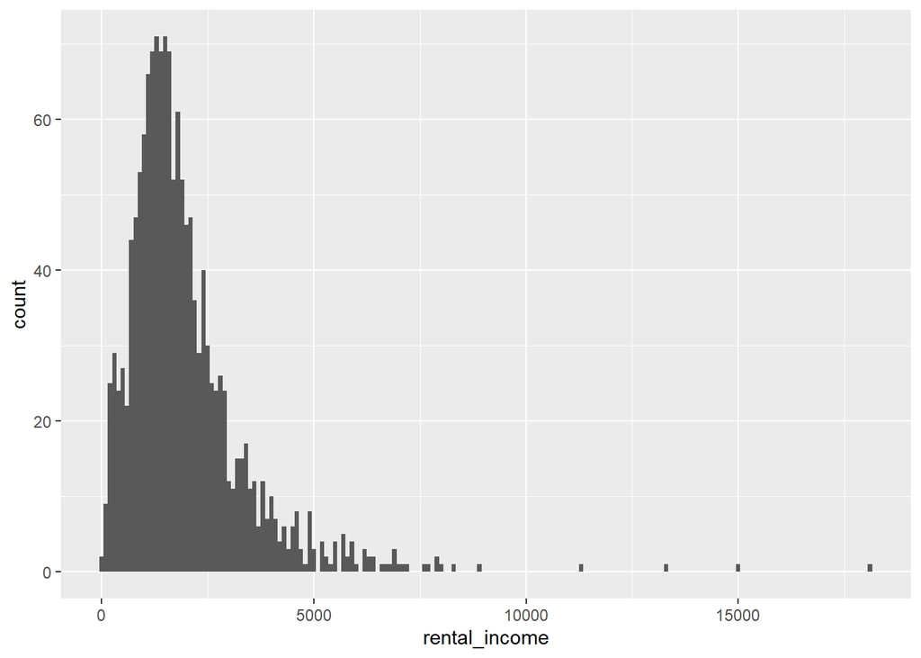

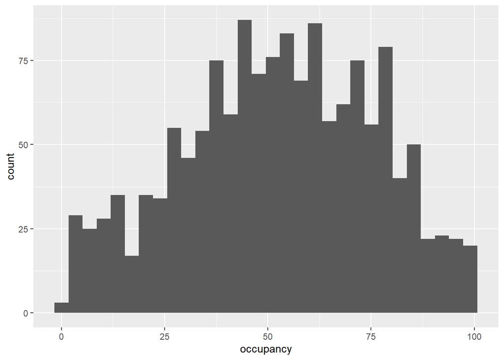

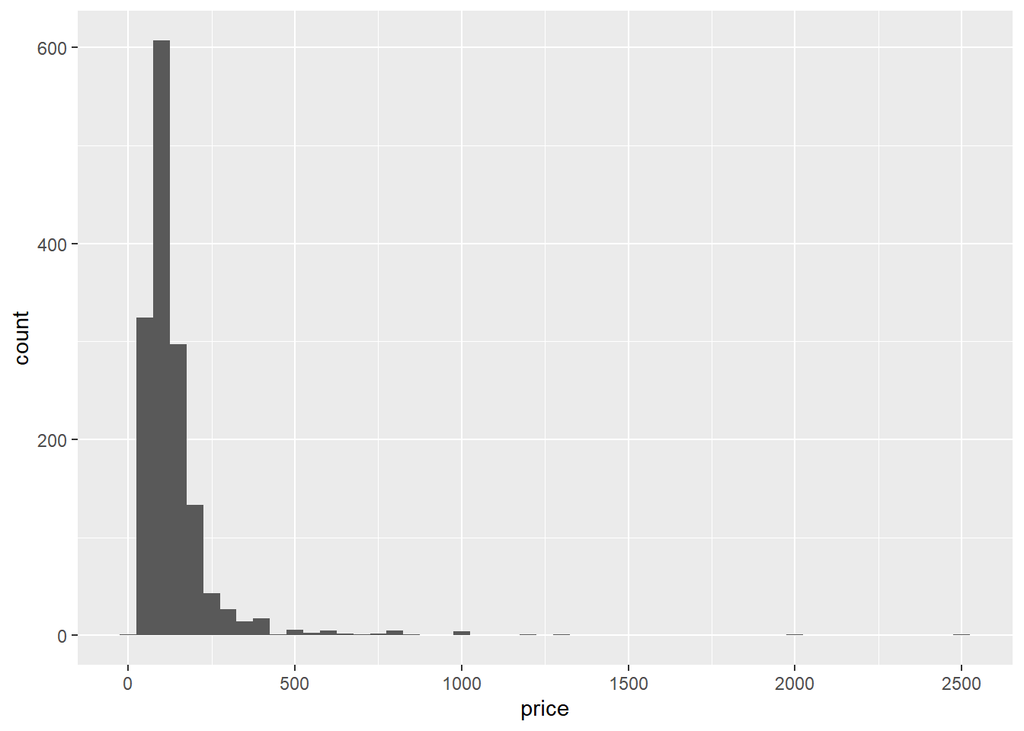

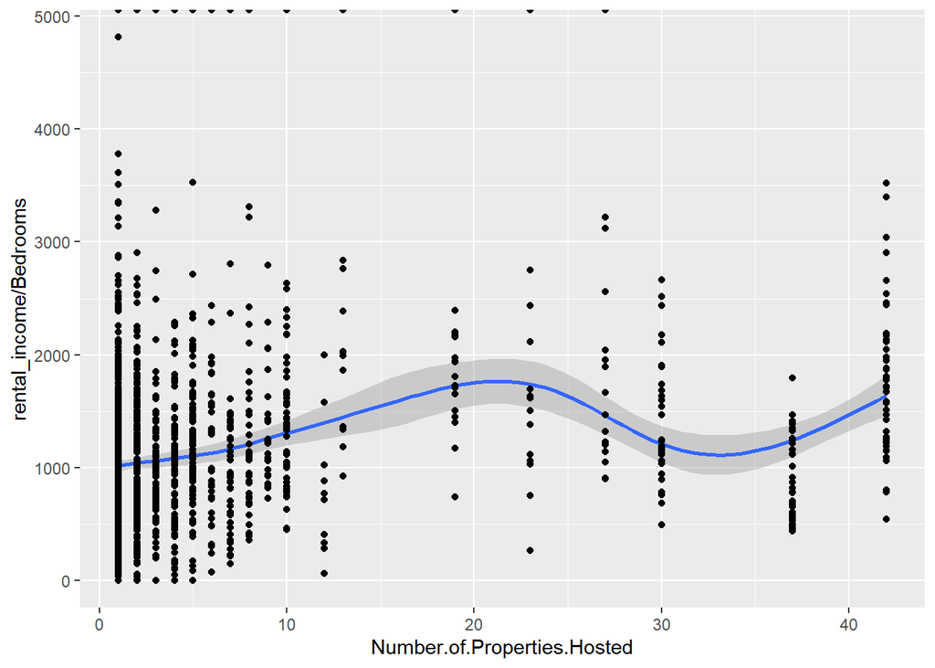

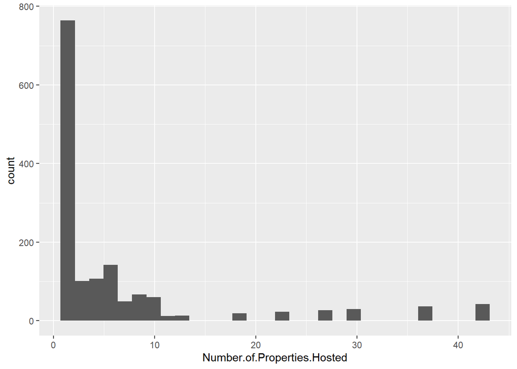

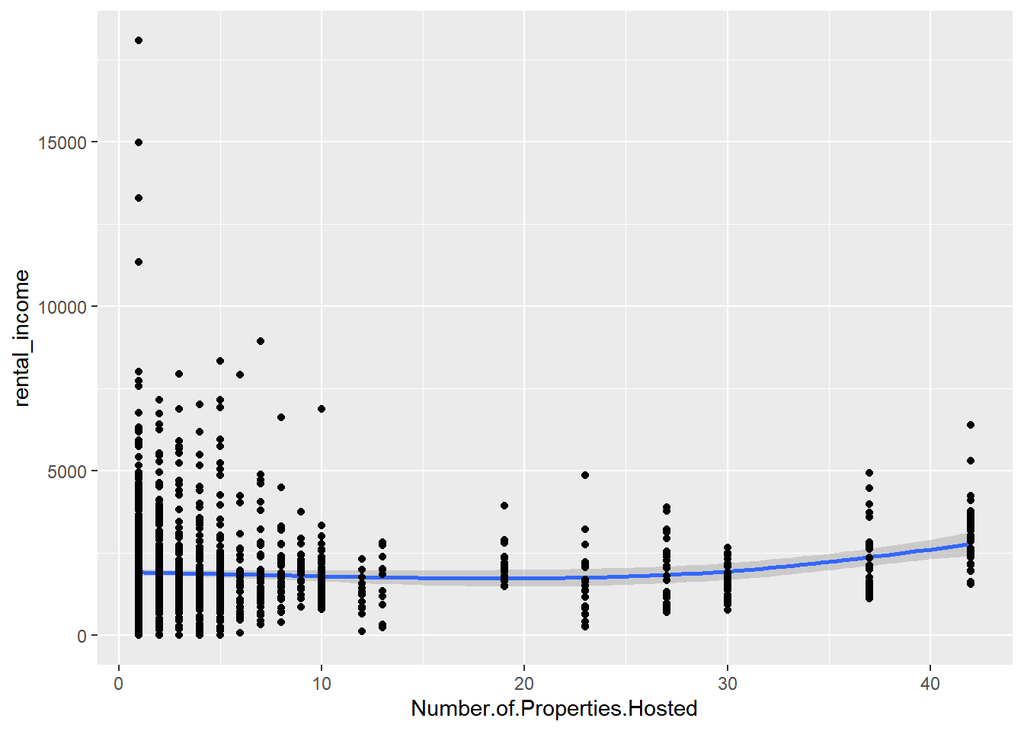

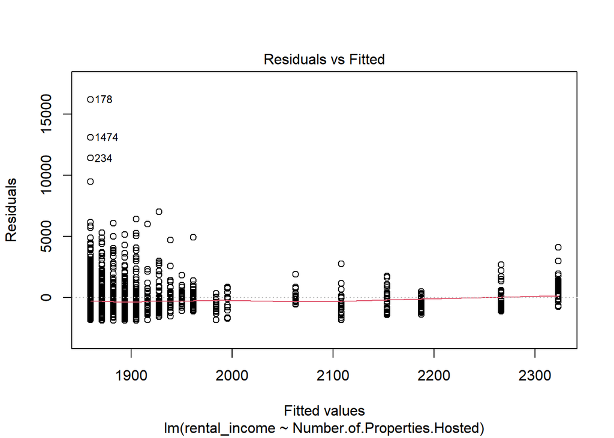

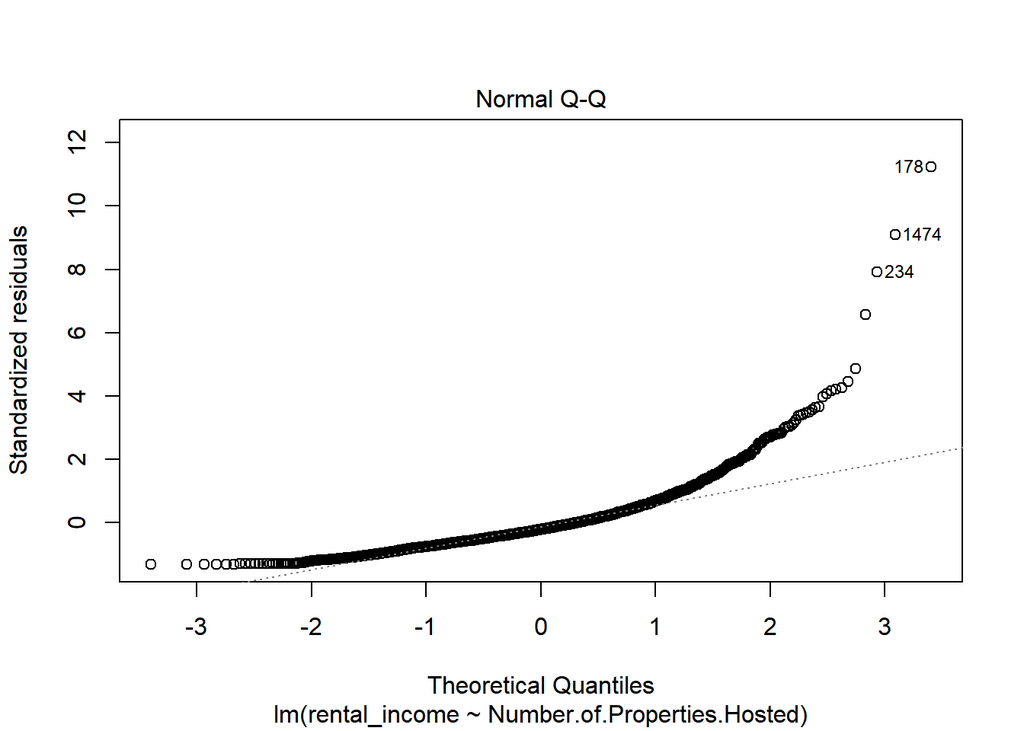

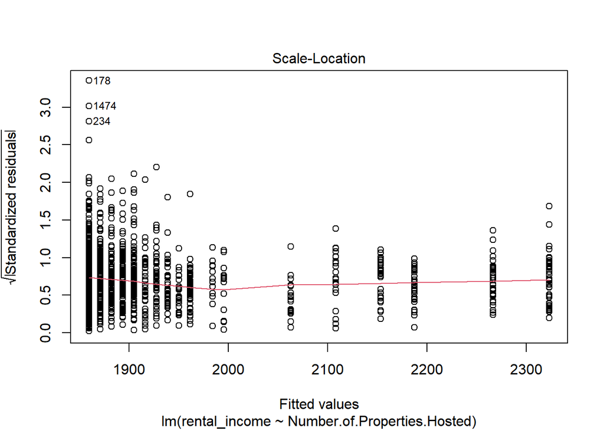

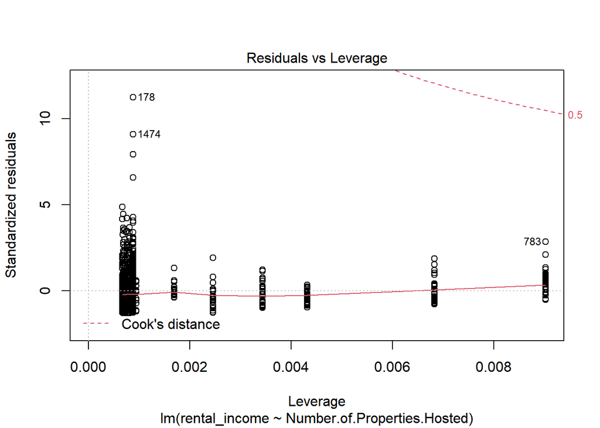

```
##                             Number.of.Properties.Hosted
## Nightly.Price                              -0.048643153
## Bedrooms                                   -0.046185102
## Beds                                       -0.030563491
## Bathrooms                                   0.038280305
## Minimum.Nights                             -0.074077580
## Maximum.Guest.Capacity                      0.012680994
## Review.Count                               -0.085495951
## Picture.Count                               0.065708884
## Check.In.Time                               0.283666779
## Check.Out.Time                             -0.139435293
## Guests.Included                            -0.102179007
## Security.Deposit                            0.002193177
## Star.Rating                                -0.180870692
## Price.per.Extra.Guest                      -0.132173845
## Cleaning.Fee                                0.019116066
## Weekend.Nightly.Price                       0.045531065
## Monthly.Price.Factor                        0.040262290
## Weekly.Price.Factor                         0.017504317
## occupancy                                   0.081395127
## rental_income                               0.078251604
## X24.hour.check.in                           0.085291998
## Accessible.height.bed                      -0.003094418
## Accessible.height.toilet                   -0.002363208
## Air.conditioning                            0.050164239
## BBQ.grill                                  -0.092870147
## Baby.bath                                  -0.053007951
## Baby.monitor                               -0.016430584
## Babysitter.recommendations                 -0.071937868
## Baking.sheet                               -0.121827709
## Barbecue.utensils                          -0.072900417
## Bath.towel                                 -0.033466235
## Bathroom.essentials                        -0.029452975
## Bathtub                                     0.126235832
## Beach.essentials                            0.002126168
## Bed.linens                                  0.189771699
## Bedroom.comforts                           -0.029452975
## Body.soap                                  -0.070033387
## Bread.maker                                -0.035707959
## Breakfast                                  -0.127922336
```

[output cut: 108 more lines]

```
## Toilet.paper                               -0.033466235
## Trash.can                                   0.040056751
## Walk.in.shower                             -0.011449896
## Washer                                      0.164498492
## Waterfront                                  0.009066195
## Well.lit.path.to.entrance                   0.145801836
## Wheelchair.accessible                      -0.040688452
## Wide.clearance.to.shower                   -0.021916904
## Wide.entrance                              -0.016430584
## Wide.entrance.for.guests                   -0.044957924
## Wide.hallways                              -0.047739153
## Wifi                                        0.003388764
## Window.guards                               0.211405612
## toilet                                     -0.021916904
## Number.of.Properties.Hosted                 1.000000000
```

Unsurprisingly, larger properties appear to earn more, although it’s important to remember that more income != more profit.

# Rooms and Rental Income

```
## # A tibble: 10 x 3
##    bedrooms Median_income Standard_Dev
##       <dbl>         <dbl>        <dbl>
##  1        0           NA           NA
##  2        1           NA           NA
##  3        2           NA           NA
##  4        3           NA           NA
##  5        4         3462.        1814.
##  6        5         4412.        3923.
##  7        6         4924         4071.
##  8        8         7145           NA
##  9        9         4602           NA
## 10       NA         1173           NA
```

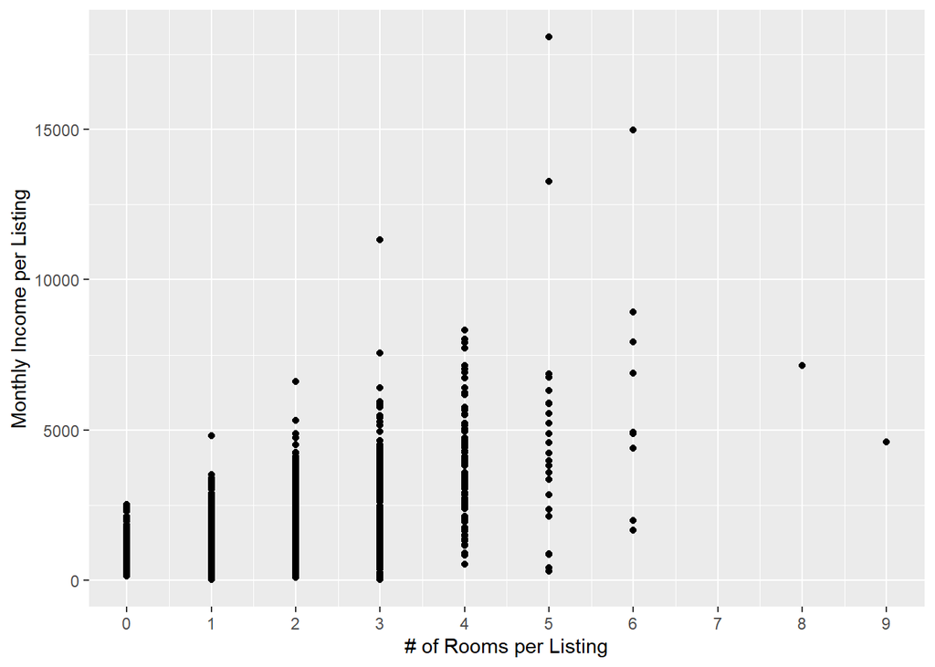

# Neighborhood and Rental Income

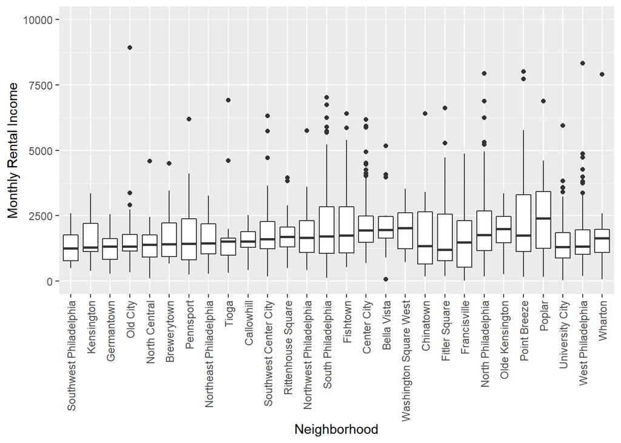

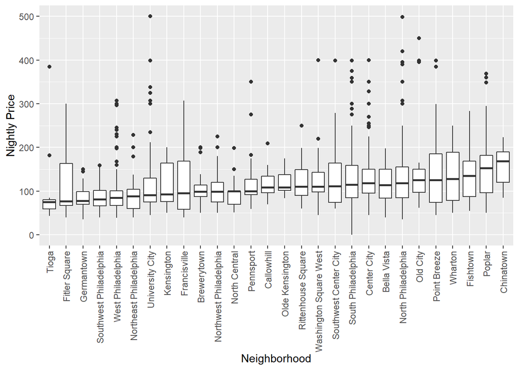

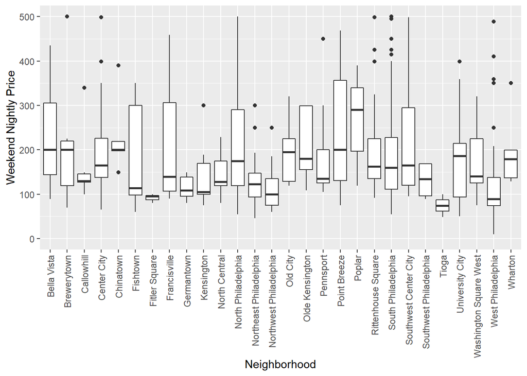

Interestingly, even though the dataset included rentals from before and after the initiation of the COVID19 quarantine in Philadelphia, listing created shortly before the quarantine didn’t seem to perform much worse than listings created after the quarantine

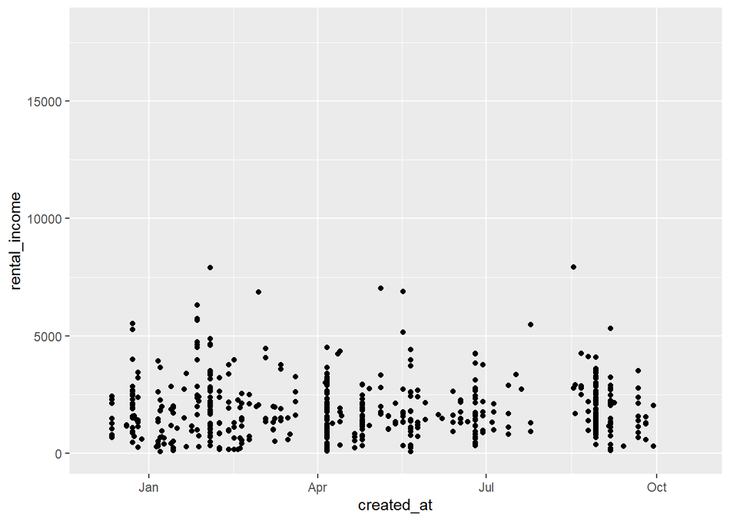

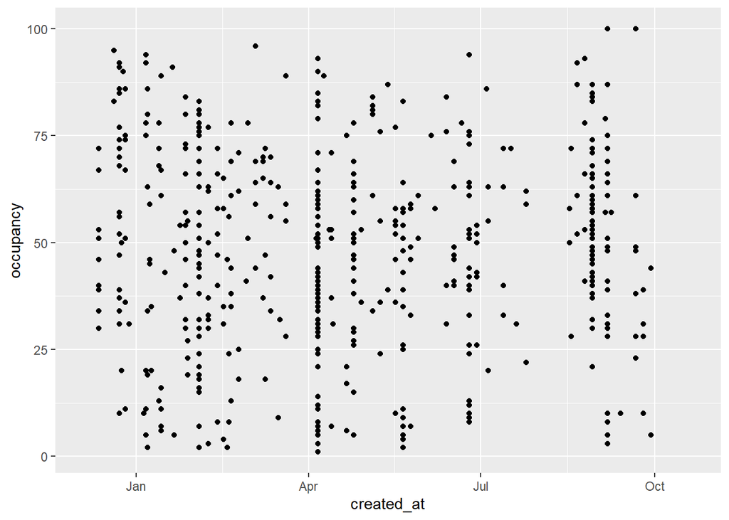

Some amenities are a lot more common than others. As you can see below, while a few amenities were present in almost every property, most amenities were listed in less than 25% of listings and no small number were available in less than 5% of listings.

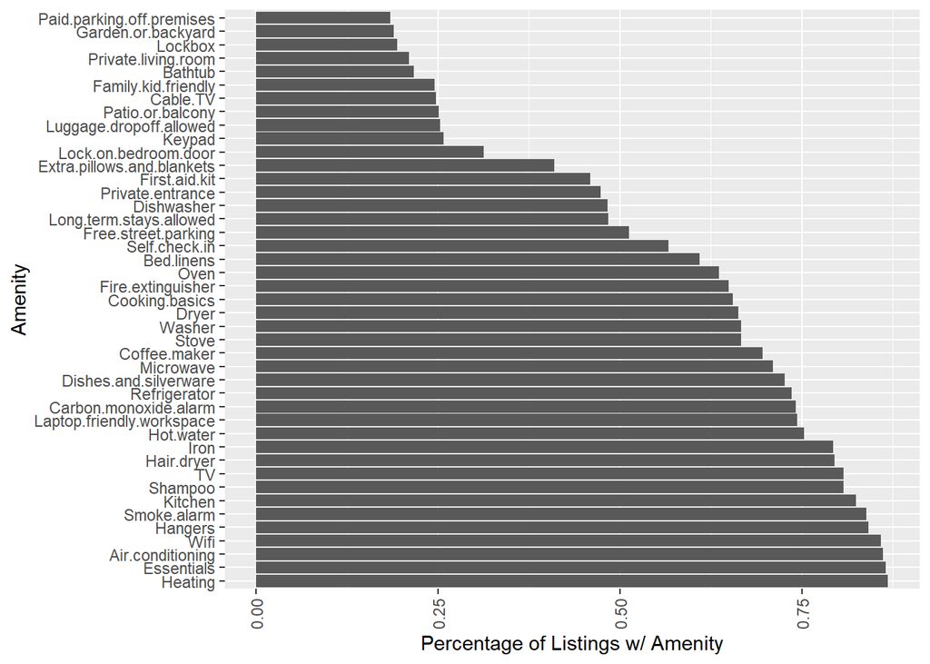

This is a major consideration and something you should consider independent of income predictions - if an amenity is particularly rare or exceedingly common then chances are the my modeling isn’t as accurate as I’d like and you’d be skip the fancy data voodoo and simply ask yourself how much more you’d pay to stay in a listing with the item you’re thinking about getting. If you wouldn’t pay an extra $20 a night to stay in a listing with a hot tub, then maybe shelling out $5k for one isn’t a great investment. Conversely, if you’ve met a lot of pruny-feet enthusiasts who decry the paucity of suitable listings in Philly, you might be on to something.

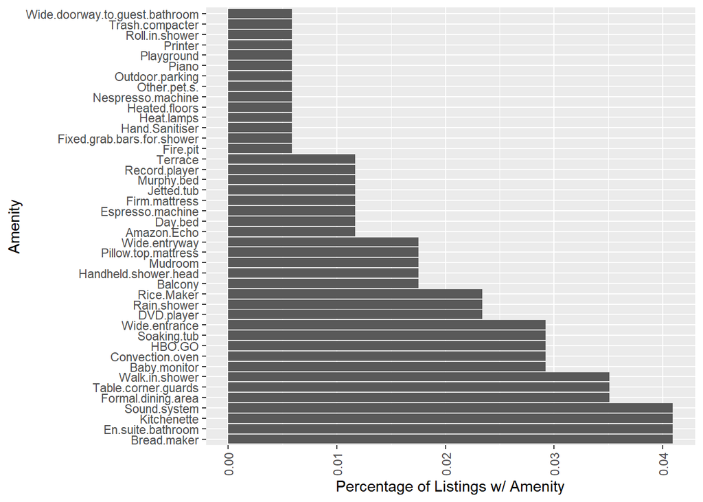

After variance drops I evaluated the number of amenities offered per listing, below.

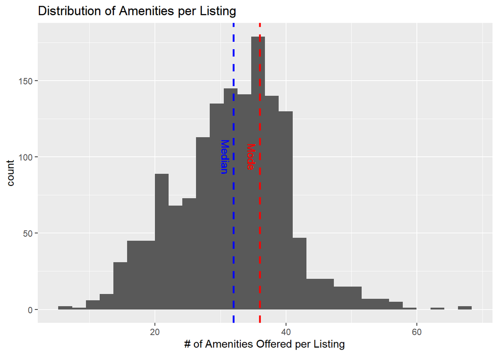

There seems to be a positive relationship between the number of amenities a listing offers and number of rooms (bathrooms plus bedrooms) per listing or the price of the listing, respectively.

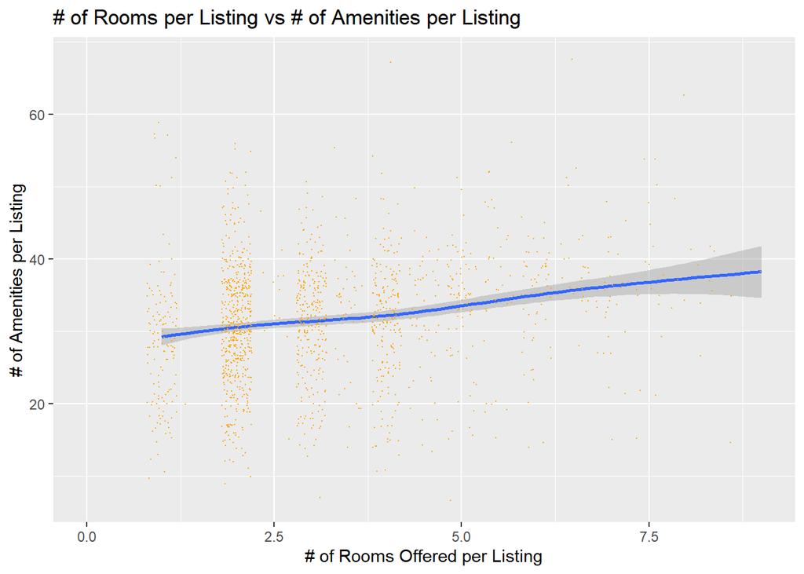

And, in general, properties that have more amenities appear to charge slightly more.

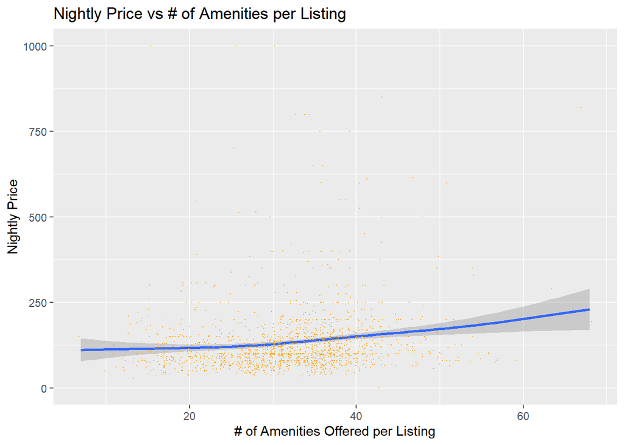

However, when related to rental income or occupancy, the number of amenities seems to be positively related only within specific tolerances. This may suggest that above a certain threshold, more amenities only overwhelm potential travelers, or, below a certain threshold, communicate disinterest on the part of the host, although limited data at particularly high or low counts creates substantial uncertainty. Of note, adding amenity count to penalized linear modeling appeared to greatly increase overfitting.

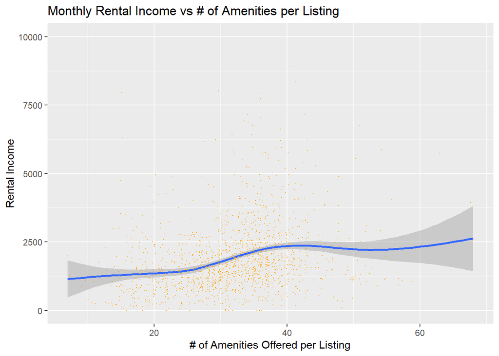

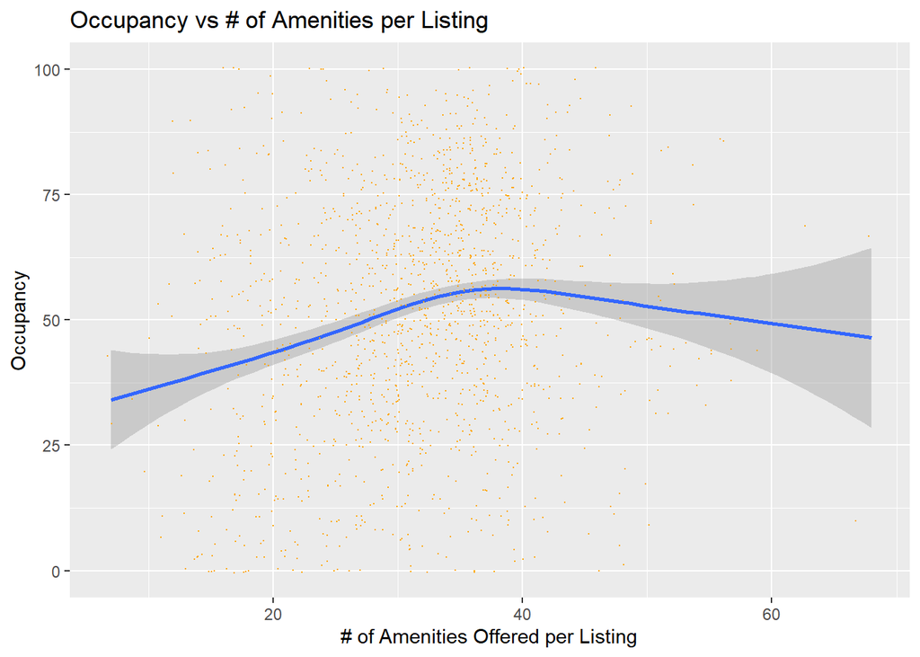

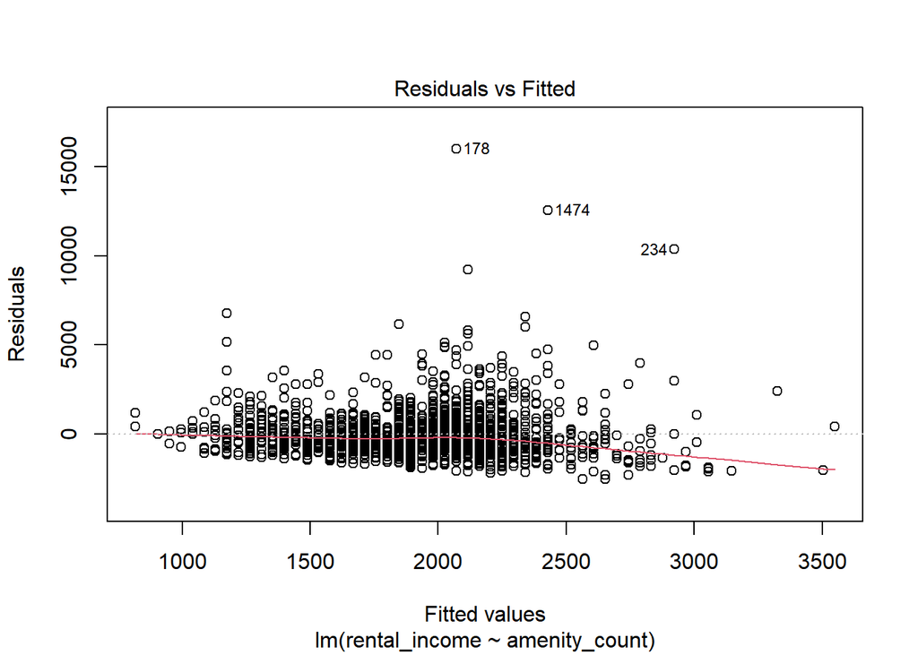

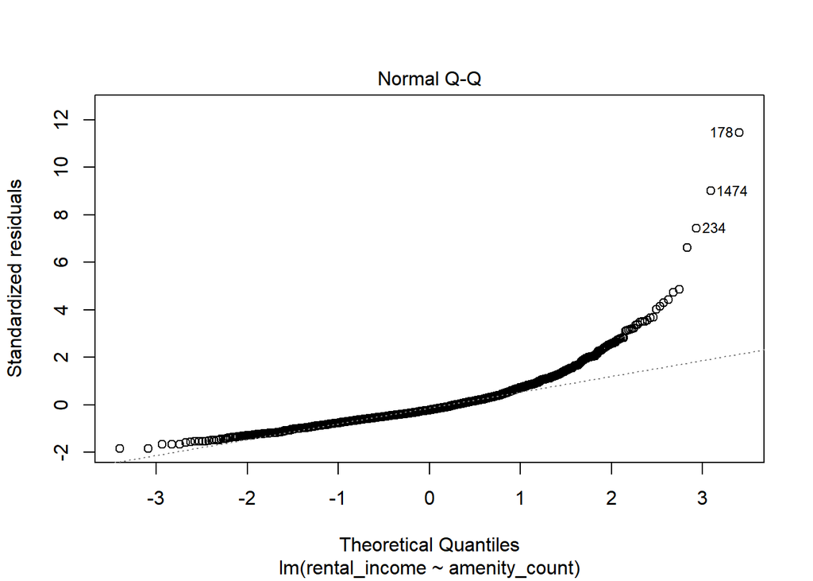

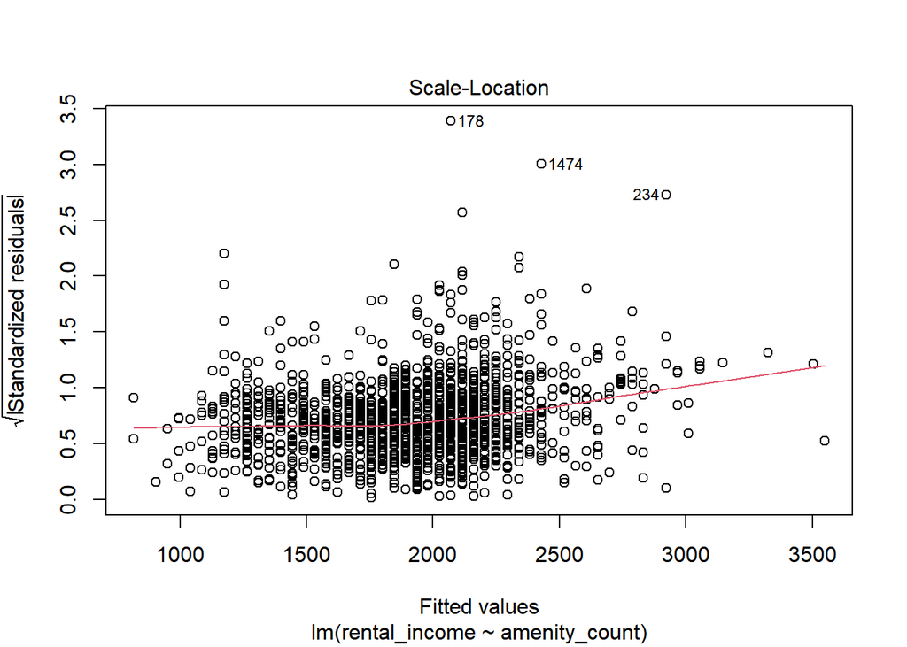

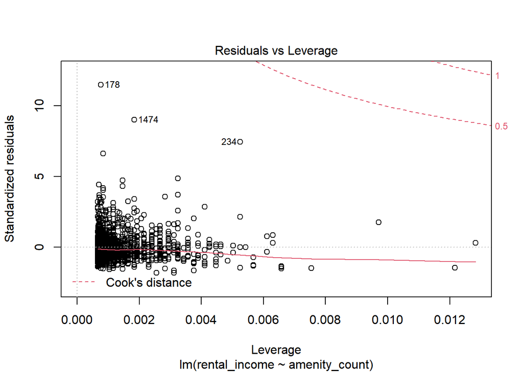